# Juvenile snowshoe hares in Bonanza Creek experimental forest

Quin Smith

11/19/2020

# A. Introduction

Snowshoe hares are an important keystone species in boreal forests. This report focuses on juvenile snowshoe hare trapping observations at the Bonanza Creek experimental forest from 1998-2012. Observations were recorded across three habitat grid zones: Riparian (`bonrip`), Black Spruce (`bonbs`), and Mature Spruce (`bonmat`) (Keiland et al. 2017).

# B. Data and analyses

Snowshoe hare observations were collected and made available by Dr. Knut Keiland, et al. as part of continued research by the Institute of Artic Biology, University of Alaska, Fairbanks. The Bonanza Creek LTER is part of the US Long Term Ecological Research Network.

# C. Exploratory findings

### i. Annual juvenile hare counts

Creates a count of the total number of juvenile hare trappings across all grid sites by year.

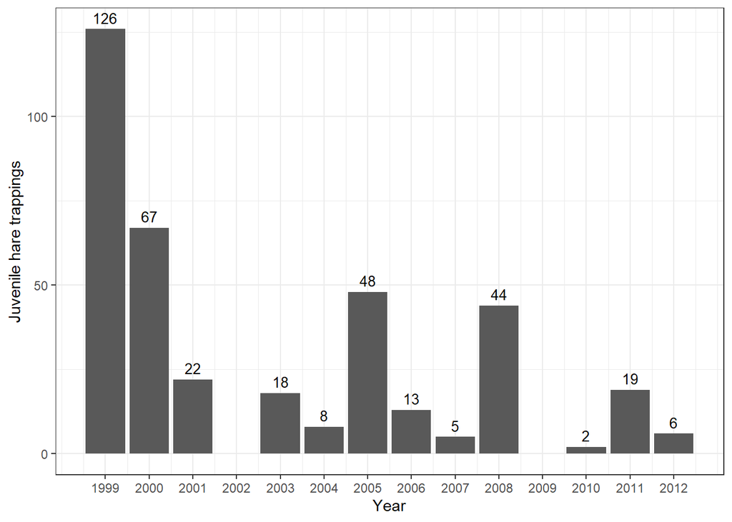

**Figure 1: Total number of juvenile snowshoe hare trappings in Bonanza Creek experimental forest by year, 1999-2012.** Graph includes trappings from three seperate grid sites: riparian habitat (bonrip), black spruce habitat (bonbs), and mature spruce habitat (bonmat). Data: Keiland et al. 2017

Discussion: There is high variability of the number of juvenile snowshoe hares trapped from 1999 to 2012 (Mean = 31.5, Median = 18.5, SD = 35.88492). The maximum number of trappings (n = 126) were in 1999 versus the minimum (n = 2) during 2010, not including the years where no juvenile hares were trapped: 1998, 2002, and 2009. From this preliminary analysis, it is difficult to see any general trends in the data. The strength of this survey is compromised from a lack of standardization of the number of traps per grid area, the number of survey days per year, the time of year, and the specificity of age of trapped hares. Moving forward, I would suggest improvements to the experimental design that might include time-series surveys with special attention given to standardizing the number of traps per grid area and specifying age to avoid missing data.

### ii. Juvenile hare weights

Creates a plot that compares **juvenile hare weights by sex and grid,** ignoring all other variables. Includes groups where these variables are not recorded (`NA`).

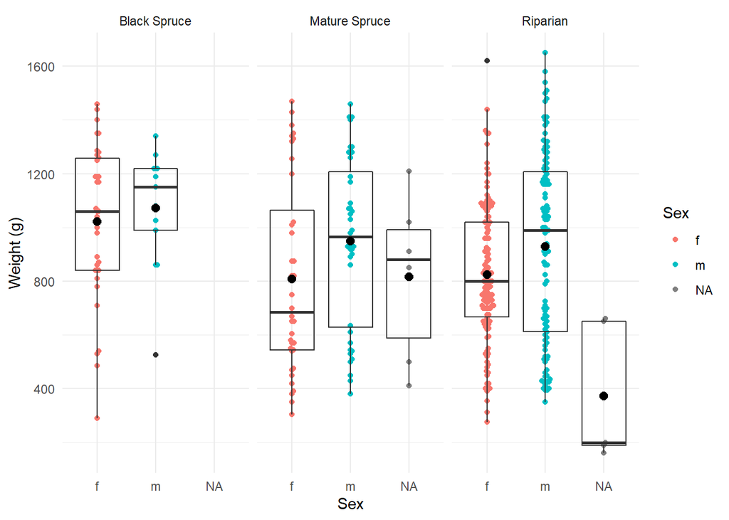

**Figure 2: Beeswarm plot showing a comparison of the weights of juvenile snowshoe hares in Bonanza experimental forest by sex and grid (1998-2012).** The plot includes data from observations where sex was not determined (sex = NA). Mean for each sample is shown as a black point. The boxplot overlays show sample median (black line), first through third quartile distribution (box), and minimums and maximums (whiskers). Outliers are shown in black at extreme edges of the plot. Data: Keiland et al. 2017

Discussion: The beeswarm plots with summary statistics overlays indicate normality of the distributions. Excluding male snowshoe hare weights in the black spruce habitat grid which has a very small sample size (n = 13), the female snowshoe hares in the mature spruce habitat grid, and the sex = NA categories, the samples display a distinct central tendency and the means and medians are close together. The box plots show that variance on either side of these central tendencies follows the general pattern for normal distribution; variance on is relatively equal on either sides.

### iii. Weight comparisons of juvenile male and female snowshoe hares

Creates a summary table of the mean, standard deviation, and sample size for all male and female juvenile snowshoe hare observations.

**Figure 3: Table showing the summary statistics of juvenile snowshoe hares weight observations in Bonanza Creek experimental forest (1998-2012).** Table includes mean weight (grams), standard deviation (grams), and sample size of male and female snowshoe hares. Data: Keiland et al. 2017.

| Sex | Mean weight (g) | Standard deviation (g) | Sample size |
| --- | --- | --- | --- |
| f | 855.3909 | 292.2526 | 200 |
| m | 945.8589 | 333.2151 | 163 |

### iv. Relationship between juvenile weight and hind foot length

The relationship between juvenile snowshoe hare weight and hind foot length is explored here (variable `hindft`, recorded in millimeters), and weight. All juvenile hares were included in this study. Creates a visualization of juvenile hare hind foot length versus weight.

The is a somewhat linear relationship between snowshoe hare weight (g) and hind foot length (mm) across the observations (Figure 4). Simple linear regression revealed that hind foot length does significantly influence snowshoe hare weight (p = 8.458368e-21). However, given the R<sup>2</sup> value (0.3), we can see that variance in hare weight is WEAKLY linearly correlated with the variance of hare hind foot length. There are likely other factors at play that influence hare weight other than hind foot length, which would be worth further investigation.

The linear regression model has an average slope of $\beta$ = 9.52 g mm<sup>-1</sup> (i.e., for each one millimeter increase in hind foot length, this model predicts an average increase in weight of 9.52 g). Hind foot length and weight are moderately, significantly, positively correlated (Pearson’s *r* = 0.55, p < 0.001). Diagnostic plots (not included) reveal that this data is skewed to the right and not perfectly normally distributed. The residuals are somewhat heteroscedastic.

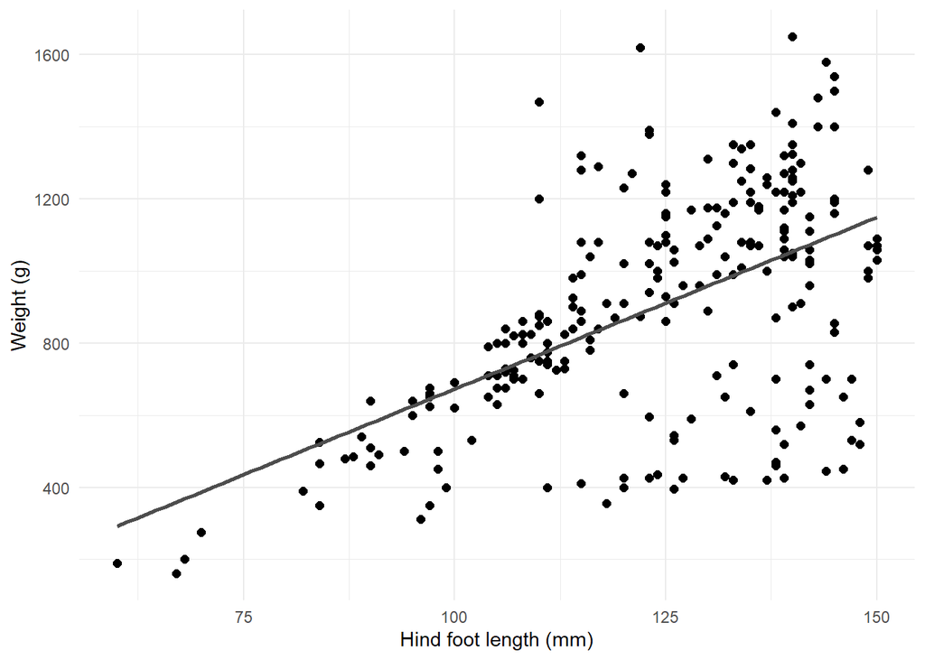

**Figure 4: Relationship between juvenile snowshoe hare weight & hind foot length, Bonanza Creek experimental forest (1998-2012)** This plot includes all observations across all grids. This plot also includes linear regression analysis, summarized in the discussion above. Data: Keiland et al. 2017

# D. Summary

Next Steps:

- Investigate other factors/covariates in addition to hind leg length that influence hare weight and use statistical methods (One-Way ANOVA) to measure their significance.
- Use multi-variate linear regression analyses to explore the relationship of covariates to hare weight.
- Explore experimental design flaws that account for missing data values. Potentially begin a new experiment using improved methods such as a time-series for future analyses.

# E. Citations

Kielland, K., F.S. Chapin, R.W. Ruess, and Bonanza Creek LTER. 2017. Snowshoe hare physical data in Bonanza Creek Experimental Forest: 1999-Present ver 22. Environmental Data Initiative. https://doi.org/10.6073/pasta/03dce4856d79b91557d8e6ce2cbcdc14